# Logistic regression

## Tasks

*Data Wrangling and Analysis.*

- Describe your work and results clearly.
- Assume the reader has an introductory course level understanding of writing and reading R code as well as statistical methods.
- Assume the reader has no previous knowledge of your data or the more advanced methods you are using.

*Preamble*

```r
# load packages
library(dplyr)
```

```r
library(ggplot2)
library(GGally)
library(openxlsx)
library(tidyr)
```

**Q2: Loading Dataset**

```r
pormath <- read.xlsx("~/R/win-library/4.0/IODS-project/data/pormath.xlsx")

colnames(pormath)
```

```
##  [1] "school"     "sex"        "age"        "address"    "famsize"
##  [6] "Pstatus"    "Medu"       "Fedu"       "Mjob"       "Fjob"
## [11] "reason"     "guardian"   "traveltime" "studytime"  "schoolsup"
## [16] "famsup"     "activities" "nursery"    "higher"     "internet"
## [21] "romantic"   "famrel"     "freetime"   "goout"      "Dalc"
## [26] "Walc"       "health"     "n"          "id.p"       "id.m"
## [31] "failures"   "paid"       "absences"   "G1"         "G2"
## [36] "G3"         "failures.p" "paid.p"     "absences.p" "G1.p"
## [41] "G2.p"       "G3.p"       "failures.m" "paid.m"     "absences.m"
## [46] "G1.m"       "G2.m"       "G3.m"       "alc_use"    "high_use"
## [51] "cid"
```

```r
date()
```

```
## [1] "Mon Nov 09 19:00:22 2020"
```

This data approach student achievement in secondary education of two Portuguese schools. The data attributes include student grades, demographic, social and school related features) and it was collected by using school reports and questionnaires. Two datasets are provided regarding the performance in two distinct subjects: Mathematics (mat) and Portuguese language (por). Please refer to [this link](https://archive.ics.uci.edu/ml/datasets/Student+Performance) to find more details.

**Q3: Chosen Vars and hypothesis**

The four interesting variables I have chosen are age (age), extra educational support (schoolsup), free time after school (freetime) and weekly study time (studytime). I draw the following hypothesis; expect a positive coefficient between alcohol consumption and age as legal age for drinking alcohol is high; expect negative coefficient between alcohol consumption and extra education support as less time is spent for leisure (drinking); expect positive coefficient between alcohol consumption and free time after school as more time is spend on leisure (drinking) and lastly expect a negative coefficient between alcohol consumption and study time as less time is spent on leisure (drinking) is more time is committed to studying.

**Q4: Visualization and relationships**

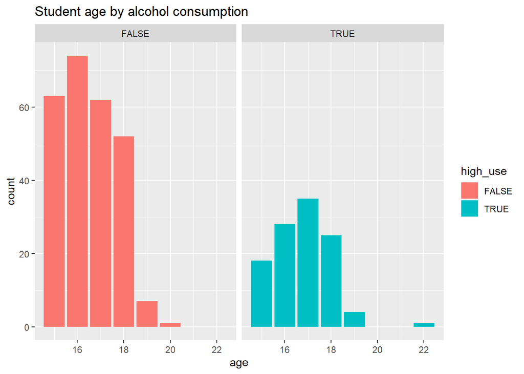

```r
#Bar plots
g1 <- ggplot(data = pormath, aes(x = age , fill = high_use))
g1 + geom_bar()+ facet_wrap("high_use")+ ggtitle("Student age by alcohol consumption")
```

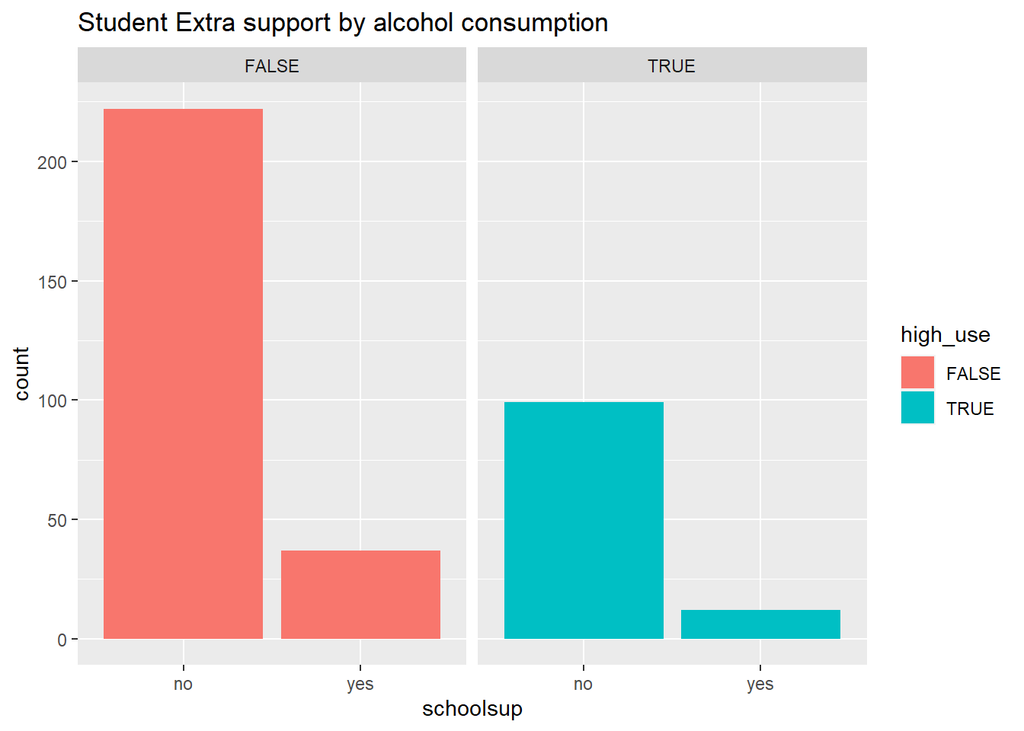

```r
g2 <- ggplot(data = pormath, aes(x = schoolsup , fill = high_use))
g2 + geom_bar()+ facet_wrap("high_use")+ ggtitle("Student Extra support by alcohol consumption")
```

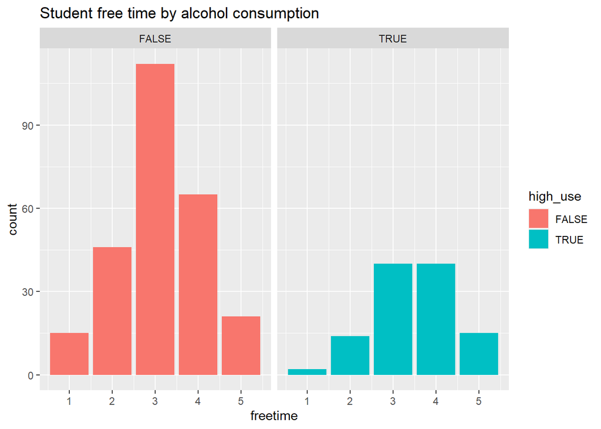

```r
g3 <- ggplot(data = pormath, aes(x = freetime , fill = high_use))
g3 + geom_bar()+ facet_wrap("high_use")+ ggtitle("Student free time by alcohol consumption")
```